# The Impact of Income and Substance Use on Health Outcomes in US Counties

Using Data from CHR 2023

Published

2025-02-25

```r
knitr::opts_chunk$set(warning = FALSE)
```

```r
library(Hmisc)
library(janitor)
library(naniar)
library(sessioninfo)
library(car)
library(mosaic)
suppressPackageStartupMessages(library(here))
library(gt)
library(glue)
library(patchwork)
library(broom)
library(rstatix)
library(tidyverse)



theme_set(theme_bw())
knitr::opts_chunk$set(comment = NA)
```

# 1 Data Ingest

```r
data_url <- "https://www.countyhealthrankings.org/sites/default/files/media/document/analytic_data2023_0.csv"

chr_2023_raw <- read_csv(data_url, skip = 1, guess_max = 4000,show_col_types = FALSE)


chr_2023_raw <- chr_2023_raw %>% filter(county_ranked == 1)

dim(chr_2023_raw)
```

```
[1] 3082  720
```

# 2 State Selection

The goal of the analysis will include all of the counties in the Unitied States of America.

```r
chr_2023 <- chr_2023_raw %>% mutate(state = factor(state))

chr_2023 %>% count(state)
```

```
# A tibble: 51 × 2
   state     n
   <fct> <int>
 1 AK       24
 2 AL       67
 3 AR       75
 4 AZ       15
 5 CA       58
 6 CO       59
 7 CT        8
 8 DC        1
 9 DE        3
10 FL       67
# ℹ 41 more rows
```

```r
nrow(chr_2023)
```

```
[1] 3082
```

There are 3082 total counties in this data set.

# 3 Variable Selection

```r
chr_2023 <- chr_2023 %>% select(fipscode,
                                county,
                                state,
                                county_ranked,
                                v002_rawvalue,
                                v063_rawvalue,
                                v011_rawvalue,
                                v009_rawvalue,
                                v143_rawvalue)
```

The selected variables for analysis include poor or fair health, median household income, adult obesity, adult smoking, and insufficient sleep. In Analysis 1, median household income serves as the predictor for the outcome variable poor or fair health. Analysis 2 examines adult smoking as a predictor of adult obesity, while Analysis 3 focuses on insufficient sleep as the primary variable of interest.

# 4 Variable Cleaning and Renaming

The selected variables were renamed to align with the data dictionary:

```r
chr_2023 <- chr_2023 %>% rename(Poor_or_fair_health = v002_rawvalue,
                    Median_household_income = v063_rawvalue,
                    Adult_obesity = v011_rawvalue,
                    adult_smoking = v009_rawvalue,
                    insufficent_sleep = v143_rawvalue) %>% mutate(Poor_or_fair_health = Poor_or_fair_health * 100,
                                                                  Median_household_income = Median_household_income / 1000,
                                                                  Adult_obesity = Adult_obesity * 100,
                                                                  adult_smoking = adult_smoking * 100,
                                                                  insufficent_sleep = insufficent_sleep * 100)
```

All variables, except for Median Household Income, were multiplied by 100 to convert their values from proportions to percentages. Median Household Income was divided by 1,000 to express it in thousands of dollars for better readability.

# 5 Creating the Analysis 2 Predictor

The percentage of adult smokers in a county will be categorized into three groups: “Low”, “Medium”, and “High” based on quantile cutoffs.

- “Low”: Counties in the bottom 40% (≤ 18.9%)
- “Medium”: Counties in the middle 20% (between 18.9% and 20.9%)
- “High”: Counties in the top 40% (≥ 20.9%)

```r
# Compute quantile cutoffs
chr_2023 %>%
  summarise(q40 = quantile(adult_smoking, c(0.4), na.rm = TRUE),  # Bottom 40% cutoff
            q60 = quantile(adult_smoking, c(0.6), na.rm = TRUE))  # Top 40% cutoff
```

```
# A tibble: 1 × 2
    q40   q60
  <dbl> <dbl>
1  18.9    21
```

```r
# Categorize adult smoking into "Low", "Medium", and "High" groups
chr_2023 <- chr_2023 %>%
  mutate(adult_smoking_grp = case_when(
    adult_smoking <= 18.9 ~ "Low",
    adult_smoking > 18.9 & adult_smoking < 20.9 ~ "Medium",
    adult_smoking >= 20.9 ~ "High")) %>%
  mutate(adult_smoking_grp = factor(adult_smoking_grp, levels = c("Low", "Medium", "High")))

# Count occurrences in each category
chr_2023 %>% count(adult_smoking_grp)
```

```
# A tibble: 4 × 2
  adult_smoking_grp     n
  <fct>             <int>
1 Low                1233
2 Medium              571
3 High               1277
4 <NA>                  1
```

The majority of counties fall into the ‘Low’ (1,233 counties) and ‘High’ (1,277 counties) smoking groups, while fewer counties (571) are classified as ‘Medium.’ Only one county has missing data.

# 6 Adding 2018 Data for the Analysis 3 Outcome

Analysis will be done with the variable insufficient sleep to determine if the sleep quality has worsened for these counties between 2018 and 2023. The 2018 data is read in with read_csv() and is joined to the original data set using the function left join().

```r
chr_2018_raw <- read_csv(suppressWarnings(here("data/raw/chr_2018.csv")), guess_max = 4000, show_col_types = FALSE)


chr_2018_raw <- chr_2018_raw %>% mutate(fipscode = as.character(fipscode))

chr_2018 <- chr_2018_raw %>% select(fipscode, v143_rawvalue)

chr_2023 <- left_join(chr_2023, chr_2018, by = "fipscode")

chr_2023 <- chr_2023 %>% rename(insufficent_sleep_2018 = v143_rawvalue) %>%
                         mutate(insufficent_sleep_2018 = insufficent_sleep_2018 * 100) %>%
                         rename(insufficent_sleep_2023 = insufficent_sleep)
```

# 7 Arranging and Saving the Analytic Tibble

```r
chr_2023 <- chr_2023 %>% select(fipscode, state, county, Poor_or_fair_health, Median_household_income, Adult_obesity, adult_smoking_grp, adult_smoking, insufficent_sleep_2023, insufficent_sleep_2018, county_ranked)

write_csv(chr_2023, here("data/processed/chr_2023.csv"))
saveRDS(chr_2023, here("data/processed/chr_2023.rds"))
```

# 8 Print the Tibble

The tibble is printed to confirm that:

1. It is a tibble (instead of a data frame or another object type).
2. All variables have the correct data types, ensuring compatibility with the analysis.

```r
chr_2023
```

```
# A tibble: 3,082 × 11
   fipscode state county          Poor_or_fair_health Median_household_income
   <chr>    <fct> <chr>                         <dbl>                   <dbl>
 1 01001    AL    Autauga County                 16.9                    66.4
 2 01003    AL    Baldwin County                 14.9                    65.7
 3 01005    AL    Barbour County                 27.5                    38.6
 4 01007    AL    Bibb County                    21.6                    48.5
 5 01009    AL    Blount County                  18.4                    56.9
 6 01011    AL    Bullock County                 29.7                    32.0
 7 01013    AL    Butler County                  22.7                    39.4
 8 01015    AL    Calhoun County                 19.6                    48.2
 9 01017    AL    Chambers County                21.5                    45.4
10 01019    AL    Cherokee County                19.3                    46.4
# ℹ 3,072 more rows
# ℹ 6 more variables: Adult_obesity <dbl>, adult_smoking_grp <fct>,
#   adult_smoking <dbl>, insufficent_sleep_2023 <dbl>,
#   insufficent_sleep_2018 <dbl>, county_ranked <dbl>
```

Expected data types:

- `fipscode` and `county` → Character (chr)
- `state` and `adult_smoking_grp` → Factor (fct)
- All other quantitative variables → Double (dbl)

# 9 Numerical Summaries

```r
describe(chr_2023)
```

```
chr_2023

 11  Variables      3082  Observations
--------------------------------------------------------------------------------
fipscode
       n  missing distinct
    3082        0     3082

lowest : 01001 01003 01005 01007 01009, highest: 56037 56039 56041 56043 56045
--------------------------------------------------------------------------------
state
       n  missing distinct
    3082        0       51

lowest : AK AL AR AZ CA, highest: VT WA WI WV WY
--------------------------------------------------------------------------------
county
       n  missing distinct
    3082        0     1846

lowest : Abbeville County          Acadia Parish             Accomack County           Ada County                Adair County
highest: Yukon-Koyukuk Census Area Yuma County               Zapata County             Zavala County             Ziebach County
--------------------------------------------------------------------------------
Poor_or_fair_health
       n  missing distinct     Info     Mean      Gmd      .05      .10
    3081        1      228        1     16.1    4.942     10.2     11.0
     .25      .50      .75      .90      .95
    12.7     15.4     19.0     22.0     24.0

lowest : 6.5  7    7.4  7.7  8   , highest: 33   33.4 34   36.5 36.8
--------------------------------------------------------------------------------
Median_household_income
       n  missing distinct     Info     Mean      Gmd      .05      .10
    3081        1     2982        1    58.91    16.17    39.18    42.52
     .25      .50      .75      .90      .95
   48.94    56.63    65.69    77.44    87.55

lowest : 25.653  28.236  28.72   29.05   29.143
highest: 133.845 134.05  141.161 142.43  153.716
--------------------------------------------------------------------------------
```

[output cut: 34 more lines]

```
    2768      314     2768        1    33.15     4.63    26.62    27.73
     .25      .50      .75      .90      .95
   30.22    33.06    36.14    38.42    39.92

lowest : 23.2268 23.3776 23.5292 23.5501 23.6942
highest: 44.8874 45.0583 45.2767 45.4021 46.7078
--------------------------------------------------------------------------------
county_ranked
       n  missing distinct     Info     Mean      Gmd
    3082        0        1        0        1        0

Value         1
Frequency  3082
Proportion    1
--------------------------------------------------------------------------------
```

# 10 The Codebook

The **chr_2023** tibble contains *3082* counties and *11* variables.

[output not shown]

**Missingness Check**

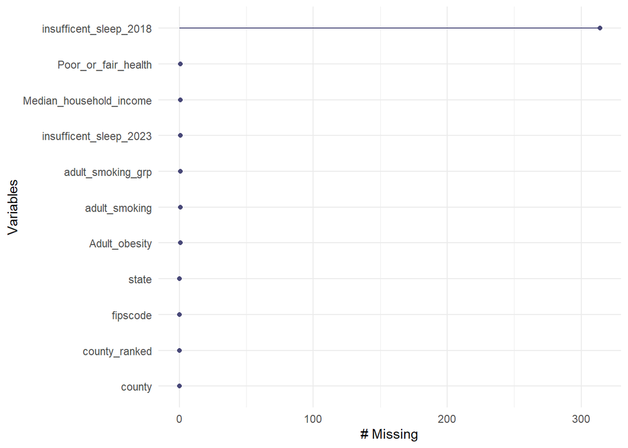

```r
gg_miss_var(chr_2023)
```

```r
# Calculate the percentage of missing values for each variable
chr_2023 %>%
  summarise(missing_percent = mean(is.na(insufficent_sleep_2018)) * 100)
```

```
# A tibble: 1 × 1
  missing_percent
            <dbl>
1            10.2
```

**Distinct Values Check**

```r
sapply(chr_2023, function(x) n_distinct(x))
```

```
               fipscode                   state                  county
                   3082                      51                    1846
    Poor_or_fair_health Median_household_income           Adult_obesity
                    229                    2983                     276
      adult_smoking_grp           adult_smoking  insufficent_sleep_2023
                      4                     237                     206
 insufficent_sleep_2018           county_ranked
                   2769                       1
```

# 11 Research Questions

## 11.1 Analysis 1 Research Question

What is the relationship between median household income and health outcomes across all U.S. counties? Counties with lower household incomes may have reduced access to healthcare and fewer economic opportunities, potentially leading to worse health outcomes.

## 11.2 Analysis 2 Research Question

Is there an association between adult smoking rates and obesity prevalence? Since nicotine is a stimulant that suppresses appetite, we hypothesize that counties with higher smoking rates will have lower obesity rates.

## 11.3 Analysis 3 Research Question

How has the average sleep quality in U.S. counties changed from 2018 to 2023?

# 12 Analysis 1

## 12.1 Variables

Two quantitative variables will be used to conduct the analysis and determine the association between them. The variables being used are `Median_household_income` as the predictor variable and `Poor_or_fair_health` as the outcome variable.`Median_household_income` represents the median reported income of households (in thousands of dollars) for a given county. `Poor_or_fair_health` is the percentage of adults self-reporting either fair or poor health in response to the question: “Would you say that in general your health is Excellent, Very Good, Good, Fair, or Poor?” The data set includes all counties in the United States.

## 12.2 Summaries

Numerical Summaries of Household income and poor of fair health outcomes:

```r
s1 <- mosaic::favstats(~ Median_household_income, data = chr_2023)
s2 <- mosaic::favstats(~ Poor_or_fair_health, data = chr_2023)
s3 <- bind_rows(list(Median_Household_Income = s1, Poor_or_fair_health = s2), .id = "id")
s3 <- s3 %>% rename(Variable = id)
s3 %>% gt() %>% fmt_number(decimals = 2)
```

| Variable | min | Q1 | median | Q3 | max | mean | sd | n | missing |
| --- | --- | --- | --- | --- | --- | --- | --- | --- | --- |
| Median_Household_Income | 25.65 | 48.94 | 56.63 | 65.69 | 153.72 | 58.91 | 15.29 | 3,081.00 | 1.00 |
| Poor_or_fair_health | 6.50 | 12.70 | 15.40 | 19.00 | 36.80 | 16.10 | 4.43 | 3,081.00 | 1.00 |

The summary statistics for the data set provide insight into the distribution of median household income and self-reported poor or fair health across 3,081 U.S. counties. The median household income ranges from $25.65K to $153.72K, with a median of $56.63K and a mean of $58.91K, suggesting a right-skewed distribution, where some counties have significantly higher incomes. The standard deviation of $15.29K indicates moderate variation in income levels across counties.

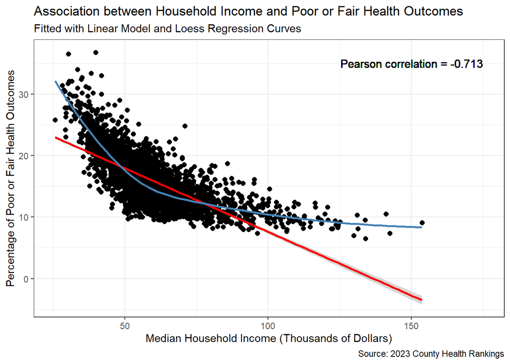

```r
# Compute Pearson correlation
income_cor <- glue("Pearson correlation = {round(cor(chr_2023$Median_household_income,
                                                      chr_2023$Poor_or_fair_health, use = 'complete.obs'), 3)}")

# Plot
ggplot(chr_2023, aes(x = Median_household_income, y = Poor_or_fair_health)) +
  geom_point(size = 2) +
  geom_smooth(method = "lm", formula = y ~ x, col = "red", se = TRUE) +
  geom_smooth(method = "loess", formula = y ~ x, col = "steelblue", se = FALSE) +
  theme_bw() +
  geom_text(aes(x = 175, y = 35, label = income_cor), hjust = 1, size = 4) +
  labs(title = "Association between Household Income and Poor or Fair Health Outcomes",
       subtitle = "Fitted with Linear Model and Loess Regression Curves",
       x = "Median Household Income (Thousands of Dollars)",
       y = "Percentage of Poor or Fair Health Outcomes",
       caption = "Source: 2023 County Health Rankings")
```

The “loess” smooth curve deviates significantly from the linear regression model, suggesting that a linear relationship may not fully capture the trend in the data. The non-linearity is particularly evident at lower income levels, where the decline in poor or fair health percentages is steep, before flattening out at higher income levels. This indicates that a simple linear model may not be the best fit for this data.

To address this, a transformation will be applied to the predictor variable (`Median_Household_Income`), and potentially the outcome variable (`Poor_or_fair_health`), to improve linearity. A Box-Cox transformation plot will be used to determine an appropriate transformation approach.

Additionally, the strong negative Pearson correlation coefficient (-0.713) suggests a moderate-to-strong inverse relationship between median household income and poor health outcomes, meaning counties with higher median incomes tend to report fewer cases of poor or fair health.

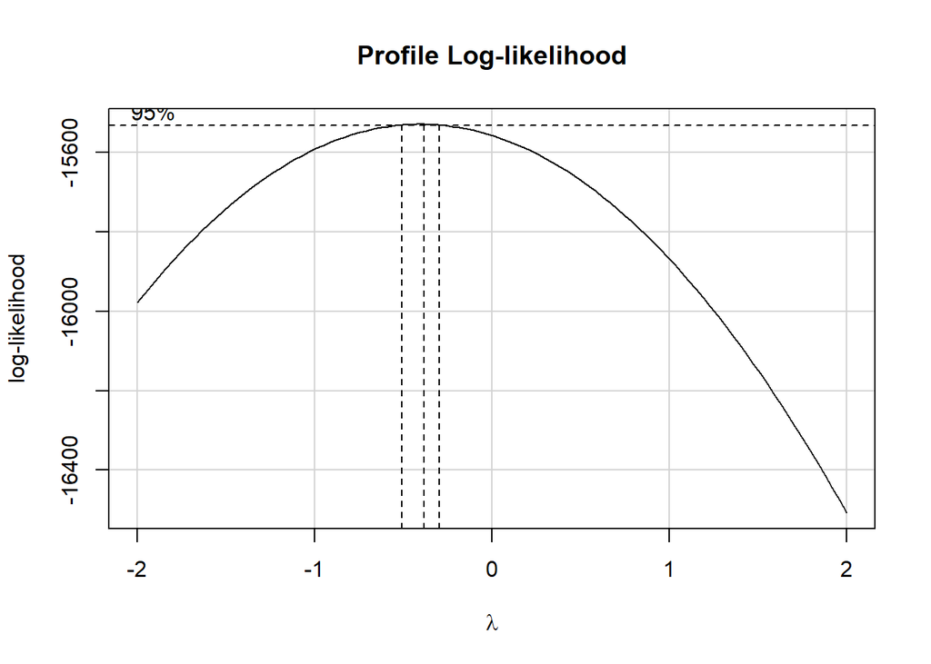

```r
boxCox(chr_2023$Poor_or_fair_health ~ chr_2023$Median_household_income)
```

```r
powerTransform(chr_2023$Poor_or_fair_health ~ chr_2023$Median_household_income)
```

```
Estimated transformation parameter
        Y1
-0.4012156
```

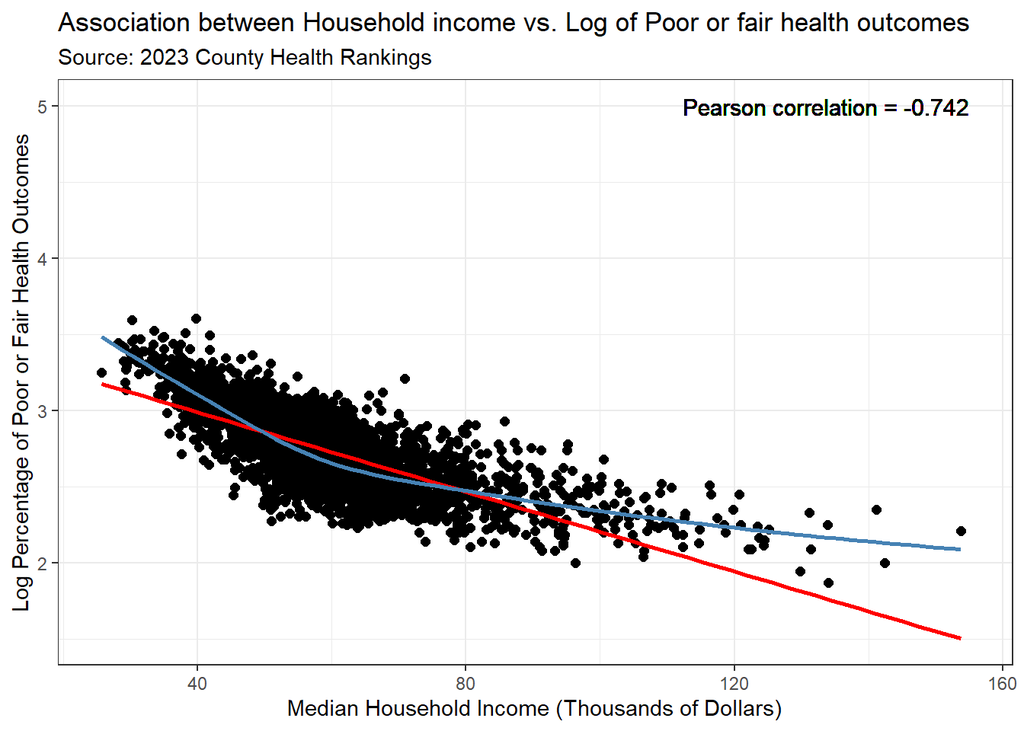

```r
# Compute Pearson correlation
income_cor <- glue("Pearson correlation = {round(cor(chr_2023$Median_household_income,
                                                      log(chr_2023$Poor_or_fair_health), use = 'complete.obs'), 3)}")

ggplot(chr_2023, aes(x = Median_household_income, y = log(Poor_or_fair_health))) +
  geom_point(size = 2) +
  geom_smooth(method = "lm", formula = y ~ x, col = "red", se = FALSE) +
  geom_smooth(method = "loess", formula = y~x, col = "steelblue", se = FALSE) +
  geom_text(aes(x = 155, y = 5, label = income_cor), hjust = 1, size = 4) +
  theme_bw() +
  labs(title = "Association between Household income vs. Log of Poor or fair health outcomes",
       x = "Median Household Income (Thousands of Dollars)",
       y = "Log Percentage of Poor or Fair Health Outcomes",
       subtitle = "Source: 2023 County Health Rankings")
```

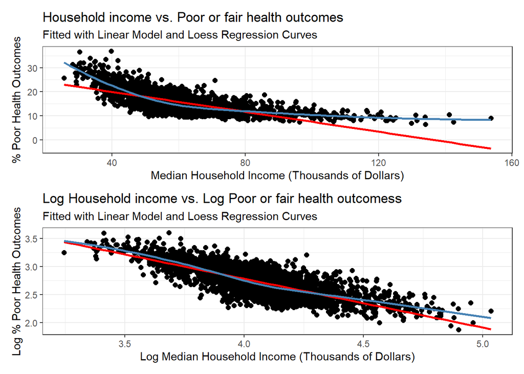

```r
p1 <- ggplot(chr_2023, aes(x = Median_household_income, y = Poor_or_fair_health)) + geom_point(size = 2) +
  geom_smooth(method = "lm", formula = y ~ x, col = "red", se = FALSE) +
  geom_smooth(method = "loess", formula = y~x, col = "steelblue", se = FALSE) + theme_bw() +
  labs(title = "Household income vs. Poor or fair health outcomes",
       subtitle = "Fitted with Linear Model and Loess Regression Curves",
       x = "Median Household Income (Thousands of Dollars)",
       y = "% Poor Health Outcomes")

p2 <- ggplot(chr_2023, aes(x = log(Median_household_income), y = log(Poor_or_fair_health))) + geom_point(size = 2) +
  geom_smooth(method = "lm", formula = y ~ x, col = "red", se = FALSE) +
  geom_smooth(method = "loess", formula = y~x, col = "steelblue", se = FALSE) + theme_bw() +
  labs(title = "Log Household income vs. Log Poor or fair health outcomess",
        subtitle = "Fitted with Linear Model and Loess Regression Curves",
       x = "Log Median Household Income (Thousands of Dollars)",
       y = "Log % Poor Health Outcomes")


p1 / p2
```

The log transformation of the `Poor_or_fair_health` outcome variable has improved the linearity of the relationship between median household income and self-reported poor or fair health outcomes. Compared to the original plot, the loess curve (blue) and the linear regression line (red) now align more closely, indicating that the transformed model better captures the underlying trend.

## 12.3 Model

```r
m1 <- lm(log(Poor_or_fair_health) ~ log(Median_household_income), data = chr_2023)

tidy(lm(log(Poor_or_fair_health) ~ log(Median_household_income), data = chr_2023),conf.int = TRUE, conf.level = 0.90) %>%
  gt() %>% fmt_number(decimals = 3)
```

| term | estimate | std.error | statistic | p.value | conf.low | conf.high |
| --- | --- | --- | --- | --- | --- | --- |
| (Intercept) | 6.264 | 0.051 | 123.920 | 0.000 | 6.181 | 6.347 |
| log(Median_household_income) | −0.870 | 0.012 | −69.794 | 0.000 | −0.891 | −0.850 |

```r
glance(lm(log(Poor_or_fair_health) ~ log(Median_household_income), data = chr_2023)) %>% select(r.squared, sigma, nobs) %>% gt() %>% fmt_number(decimals = c(3))
```

| r.squared | sigma | nobs |
| --- | --- | --- |
| 0.613 | 0.168 | 3,081.000 |

The regression model estimates the relationship between median household income and poor or fair health outcomes using a log-log transformation. The resulting equation, indicates that a 1% increase in median household income is associated with an 0.87% decrease in the percentage of adults reporting poor or fair health. This suggests a strong negative relationship between income and poor health outcomes, meaning counties with higher median household incomes tend to have fewer residents reporting poor or fair health.

The model was fitted to 3,081 observations and explains 61.3% of the variance in poor health outcomes (R² = 0.613), suggesting a moderately strong fit. The residual standard error (σ = 0.168) reflects the typical deviation of observed values from predictions in the log-transformed scale. Additionally, the p-values for both the intercept and slope are highly significant, confirming a statistically meaningful relationship between household income and health outcomes. This analysis provides strong evidence that higher income levels are linked to better self-reported health outcomes, reinforcing the idea that economic factors play a critical role in public health disparities.

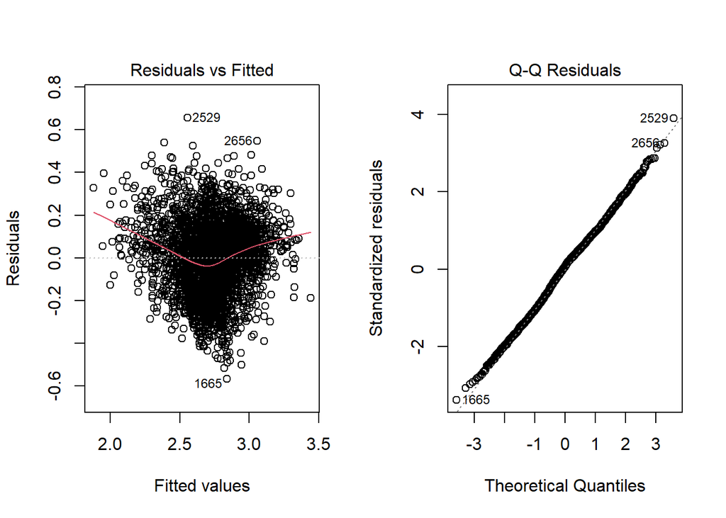

```r
par(mfrow=c(1,2)); plot(m1, which = 1:2); par(mfrow = c(1,1))
```

The Residuals vs. Fitted plot assesses the assumption of homoscedasticity (constant variance of residuals) and linear relationship. The red loess curve shows a slight curvature, indicating that the model may not fully capture a potential non-linear pattern in the data. Additionally, the spread of residuals appears to narrow at lower fitted values and widen at higher fitted values, suggesting some heteroscedasticity (non-constant variance). While not extreme, this pattern indicates that the model might benefit from further refinements, such as checking interactions or considering additional transformations.

The Q-Q Plot (right) evaluates the normality of residuals, a key assumption for reliable hypothesis testing and confidence intervals. The residuals mostly follow the theoretical normal distribution, aligning well along the 45-degree reference line. However, there are some deviations at the tails, particularly at the upper end, where a few extreme residuals (outliers) deviate from normality. This suggests that while the residuals are approximately normal, there may be some influence from high-leverage points or outliers that could impact model accuracy.

Overall, while the model performs reasonably well, the presence of slight heteroscedasticity and minor non-normality suggests that additional diagnostic tests (such as other transformations or robust regression techniques) may be useful to further improve model fit and reliability.

```r
chr_2023_aug <- augment(m1, newdata = chr_2023)

chr_2023_aug %>% select(state, county, Poor_or_fair_health, Median_household_income, .fitted, .resid) %>%
  mutate(std_resid_manual = .resid / sd(.resid, na.rm = TRUE)) -> cc_high

cc_high %>% arrange(desc(std_resid_manual)) %>% head(n = 2)
```

```
# A tibble: 2 × 7
  state county         Poor_or_fair_health Median_household_inc…¹ .fitted .resid
  <fct> <chr>                        <dbl>                  <dbl>   <dbl>  <dbl>
1 TX    Dallam County                 24.8                   70.9    2.55  0.656
2 TX    Presidio Coun…                36.8                   39.8    3.06  0.548
# ℹ abbreviated name: ¹Median_household_income
# ℹ 1 more variable: std_resid_manual <dbl>
```

## 12.4 Conclusions

This analysis aimed to determine whether counties with higher median household incomes are associated with a lower percentage of adults reporting poor or fair health outcomes. By fitting a log-log linear model, we observed a strong negative relationship between these two variables, where a 1% increase in median household income is associated with an estimated 0.87% decrease in the percentage of adults reporting poor or fair health. The 90% confidence interval for the income coefficient is [-0.891, -0.850], confirming that the effect is statistically significant and suggesting a consistent inverse association between income and health outcomes.The model achieved an R-squared value of 0.613, meaning it explains 61.3% of the variability in poor or fair health outcomes across U.S. counties. While this indicates a moderately strong fit, there remains some unexplained variation, which may be influenced by additional socioeconomic or healthcare access factors not accounted for in this model.

A key limitation arises from the residuals vs. fitted plot, which indicates some heteroscedasticity, meaning the variance of residuals is not constant across income levels. This is particularly noticeable at the lower and upper ends of the income distribution, suggesting that the predictive power of the model may be weaker for very low- or high-income counties. Additionally, the Q-Q plot shows minor deviations from normality, with a few high-leverage outliers. These extreme residuals suggest that certain counties have significantly different actual health outcomes than what the model predicts, potentially due to unmeasured regional or policy differences.

To improve the model’s predictive power and address heteroscedasticity, future analysis could explore alternative transformations, such as:

- A generalized linear model (GLM) with a different link function, which may better capture the relationship.
- Additional socioeconomic predictors, such as education levels, healthcare access, or employment rates, to enhance explanatory power.
- A weighted regression approach, where counties with extreme values contribute proportionally less to the model.
- Robust regression techniques, which reduce the influence of outliers and improve model stability.

Despite these limitations, the analysis provides strong evidence that higher household incomes are associated with better self-reported health outcomes, reinforcing the broader understanding of the relationship between economic conditions and public health.

# 13 Analysis 2

## 13.1 Variables

`Adult_Obesity` is an age-adjusted quantitative variable that measures the percentage of the adult population that reported a body mass index (BMI) greater than or equal to 30 kg/m^2. The data was collected through self-reported surveys, where adults reported their height and weight, from which BMI was calculated.